# Risk Factor Analysis

## Outcome Variable

**Outcome Variable:** y_rate_len

## Predictor Variables

**Intervention Variable:** fhtcm

**Adjustment Set:**

unadjusted

## Stratifying Variables

The analysis was stratified on these variable(s):

- agecat
- studyid
- country

## Data Summary

| agecat | studyid | country | fhtcm | n_cell | n |
| --- | --- | --- | --- | --- | --- |
| 0-3 months | ki1000304b-SAS-CompFeed | INDIA | >=167 cm | 326 | 716 |
| 0-3 months | ki1000304b-SAS-CompFeed | INDIA | <162 cm | 184 | 716 |
| 0-3 months | ki1000304b-SAS-CompFeed | INDIA | [162-167) cm | 206 | 716 |
| 0-3 months | ki1101329-Keneba | GAMBIA | >=167 cm | 631 | 965 |
| 0-3 months | ki1101329-Keneba | GAMBIA | <162 cm | 75 | 965 |
| 0-3 months | ki1101329-Keneba | GAMBIA | [162-167) cm | 259 | 965 |
| 0-3 months | ki1119695-PROBIT | BELARUS | >=167 cm | 10773 | 11500 |
| 0-3 months | ki1119695-PROBIT | BELARUS | <162 cm | 151 | 11500 |
| 0-3 months | ki1119695-PROBIT | BELARUS | [162-167) cm | 576 | 11500 |
| 0-3 months | ki1135781-COHORTS | GUATEMALA | >=167 cm | 25 | 180 |
| 0-3 months | ki1135781-COHORTS | GUATEMALA | <162 cm | 106 | 180 |
| 0-3 months | ki1135781-COHORTS | GUATEMALA | [162-167) cm | 49 | 180 |
| 3-6 months | ki1000304b-SAS-CompFeed | INDIA | >=167 cm | 308 | 682 |
| 3-6 months | ki1000304b-SAS-CompFeed | INDIA | <162 cm | 175 | 682 |
| 3-6 months | ki1000304b-SAS-CompFeed | INDIA | [162-167) cm | 199 | 682 |
| 3-6 months | ki1101329-Keneba | GAMBIA | >=167 cm | 673 | 1037 |
| 3-6 months | ki1101329-Keneba | GAMBIA | <162 cm | 74 | 1037 |
| 3-6 months | ki1101329-Keneba | GAMBIA | [162-167) cm | 290 | 1037 |
| 3-6 months | ki1119695-PROBIT | BELARUS | >=167 cm | 9473 | 10104 |
| 3-6 months | ki1119695-PROBIT | BELARUS | <162 cm | 129 | 10104 |
| 3-6 months | ki1119695-PROBIT | BELARUS | [162-167) cm | 502 | 10104 |
| 3-6 months | ki1135781-COHORTS | GUATEMALA | >=167 cm | 37 | 261 |
| 3-6 months | ki1135781-COHORTS | GUATEMALA | <162 cm | 148 | 261 |
| 3-6 months | ki1135781-COHORTS | GUATEMALA | [162-167) cm | 76 | 261 |
| 6-12 months | ki1000304b-SAS-CompFeed | INDIA | >=167 cm | 313 | 679 |
| 6-12 months | ki1000304b-SAS-CompFeed | INDIA | <162 cm | 164 | 679 |
| 6-12 months | ki1000304b-SAS-CompFeed | INDIA | [162-167) cm | 202 | 679 |
| 6-12 months | ki1000304b-SAS-FoodSuppl | INDIA | >=167 cm | 89 | 328 |
| 6-12 months | ki1000304b-SAS-FoodSuppl | INDIA | <162 cm | 132 | 328 |
| 6-12 months | ki1000304b-SAS-FoodSuppl | INDIA | [162-167) cm | 107 | 328 |
| 6-12 months | ki1101329-Keneba | GAMBIA | >=167 cm | 635 | 1005 |
| 6-12 months | ki1101329-Keneba | GAMBIA | <162 cm | 78 | 1005 |
| 6-12 months | ki1101329-Keneba | GAMBIA | [162-167) cm | 292 | 1005 |
| 6-12 months | ki1119695-PROBIT | BELARUS | >=167 cm | 9248 | 9870 |
| 6-12 months | ki1119695-PROBIT | BELARUS | <162 cm | 124 | 9870 |
| 6-12 months | ki1119695-PROBIT | BELARUS | [162-167) cm | 498 | 9870 |
| 6-12 months | ki1135781-COHORTS | GUATEMALA | >=167 cm | 45 | 329 |
| 6-12 months | ki1135781-COHORTS | GUATEMALA | <162 cm | 192 | 329 |
| 6-12 months | ki1135781-COHORTS | GUATEMALA | [162-167) cm | 92 | 329 |
| 12-24 months | ki1101329-Keneba | GAMBIA | >=167 cm | 583 | 931 |
| 12-24 months | ki1101329-Keneba | GAMBIA | <162 cm | 73 | 931 |
| 12-24 months | ki1101329-Keneba | GAMBIA | [162-167) cm | 275 | 931 |
| 12-24 months | ki1119695-PROBIT | BELARUS | >=167 cm | 2169 | 2320 |
| 12-24 months | ki1119695-PROBIT | BELARUS | <162 cm | 38 | 2320 |
| 12-24 months | ki1119695-PROBIT | BELARUS | [162-167) cm | 113 | 2320 |
| 12-24 months | ki1135781-COHORTS | GUATEMALA | >=167 cm | 58 | 421 |
| 12-24 months | ki1135781-COHORTS | GUATEMALA | <162 cm | 244 | 421 |
| 12-24 months | ki1135781-COHORTS | GUATEMALA | [162-167) cm | 119 | 421 |

The following strata were considered:

- agecat: 0-3 months, studyid: ki1000304b-SAS-CompFeed, country: INDIA
- agecat: 0-3 months, studyid: ki1101329-Keneba, country: GAMBIA
- agecat: 0-3 months, studyid: ki1119695-PROBIT, country: BELARUS
- agecat: 0-3 months, studyid: ki1135781-COHORTS, country: GUATEMALA
- agecat: 12-24 months, studyid: ki1101329-Keneba, country: GAMBIA
- agecat: 12-24 months, studyid: ki1119695-PROBIT, country: BELARUS
- agecat: 12-24 months, studyid: ki1135781-COHORTS, country: GUATEMALA
- agecat: 3-6 months, studyid: ki1000304b-SAS-CompFeed, country: INDIA
- agecat: 3-6 months, studyid: ki1101329-Keneba, country: GAMBIA
- agecat: 3-6 months, studyid: ki1119695-PROBIT, country: BELARUS
- agecat: 3-6 months, studyid: ki1135781-COHORTS, country: GUATEMALA
- agecat: 6-12 months, studyid: ki1000304b-SAS-CompFeed, country: INDIA
- agecat: 6-12 months, studyid: ki1000304b-SAS-FoodSuppl, country: INDIA
- agecat: 6-12 months, studyid: ki1101329-Keneba, country: GAMBIA
- agecat: 6-12 months, studyid: ki1119695-PROBIT, country: BELARUS
- agecat: 6-12 months, studyid: ki1135781-COHORTS, country: GUATEMALA

## Methods Detail

We’re interested in the causal parameters $E[Y_a]$ for all values of $a \in \mathcal{A}$. These parameters represent the mean outcome if, possibly contrary to fact, we intervened to set all units to have $A=a$. Under the randomization and positivity assumptions, these are identified by the statistical parameters $\psi_a=E_W[E_{Y|A,W}(Y|A=a,W)]$. In addition, we’re interested in the mean of $Y$, $E[Y]$ under no intervention (the observed mean). We will estimate these parameters by using SuperLearner to fit the relevant likelihood factors – $E_{Y|A,W}(Y|A=a,W)$ and $p(A=a|W)$, and then updating our likelihood fit using a joint TMLE.

For unadjusted analyses ($W=\{\}$), initial likelihoods were estimated using Lrnr_glm to estimate the simple $E(Y|A)$ and Lrnr_mean to estimate $p(A)$. For adjusted analyses, a small library containing Lrnr_glmnet, Lrnr_xgboost, and Lrnr_mean was used.

# Results Detail

## Results Plots

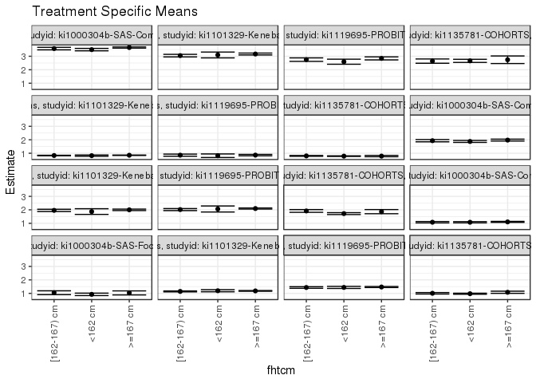

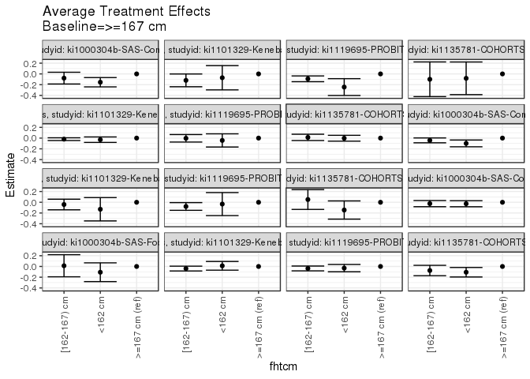

## Results Table

### Parameter: TSM

| agecat | studyid | country | intervention_level | baseline_level | estimate | ci_lower | ci_upper |
| --- | --- | --- | --- | --- | --- | --- | --- |
| 0-3 months | ki1000304b-SAS-CompFeed | INDIA | >=167 cm | NA | 3.6468114 | 3.6033788 | 3.6902440 |
| 0-3 months | ki1000304b-SAS-CompFeed | INDIA | <162 cm | NA | 3.4920879 | 3.4027512 | 3.5814246 |
| 0-3 months | ki1000304b-SAS-CompFeed | INDIA | [162-167) cm | NA | 3.5682294 | 3.4747579 | 3.6617010 |
| 0-3 months | ki1101329-Keneba | GAMBIA | >=167 cm | NA | 3.1667466 | 3.0969989 | 3.2364943 |
| 0-3 months | ki1101329-Keneba | GAMBIA | <162 cm | NA | 3.0954520 | 2.8802077 | 3.3106962 |
| 0-3 months | ki1101329-Keneba | GAMBIA | [162-167) cm | NA | 3.0466623 | 2.9502925 | 3.1430321 |
| 0-3 months | ki1119695-PROBIT | BELARUS | >=167 cm | NA | 2.8412635 | 2.7290976 | 2.9534295 |
| 0-3 months | ki1119695-PROBIT | BELARUS | <162 cm | NA | 2.5961163 | 2.4085600 | 2.7836725 |
| 0-3 months | ki1119695-PROBIT | BELARUS | [162-167) cm | NA | 2.7499467 | 2.6199767 | 2.8799166 |
| 0-3 months | ki1135781-COHORTS | GUATEMALA | >=167 cm | NA | 2.7402067 | 2.4590963 | 3.0213171 |
| 0-3 months | ki1135781-COHORTS | GUATEMALA | <162 cm | NA | 2.6581135 | 2.5422535 | 2.7739735 |
| 0-3 months | ki1135781-COHORTS | GUATEMALA | [162-167) cm | NA | 2.6402523 | 2.4814604 | 2.7990443 |
| 3-6 months | ki1000304b-SAS-CompFeed | INDIA | >=167 cm | NA | 1.9759003 | 1.9057450 | 2.0460556 |
| 3-6 months | ki1000304b-SAS-CompFeed | INDIA | <162 cm | NA | 1.8770998 | 1.8034484 | 1.9507513 |
| 3-6 months | ki1000304b-SAS-CompFeed | INDIA | [162-167) cm | NA | 1.9332958 | 1.8486358 | 2.0179559 |
| 3-6 months | ki1101329-Keneba | GAMBIA | >=167 cm | NA | 2.0003581 | 1.9461897 | 2.0545264 |
| 3-6 months | ki1101329-Keneba | GAMBIA | <162 cm | NA | 1.8704267 | 1.6601132 | 2.0807401 |
| 3-6 months | ki1101329-Keneba | GAMBIA | [162-167) cm | NA | 1.9588819 | 1.8760217 | 2.0417421 |
| 3-6 months | ki1119695-PROBIT | BELARUS | >=167 cm | NA | 2.0959961 | 2.0549214 | 2.1370707 |
| 3-6 months | ki1119695-PROBIT | BELARUS | <162 cm | NA | 2.0625817 | 1.8383679 | 2.2867954 |
| 3-6 months | ki1119695-PROBIT | BELARUS | [162-167) cm | NA | 2.0180506 | 1.9434364 | 2.0926648 |
| 3-6 months | ki1135781-COHORTS | GUATEMALA | >=167 cm | NA | 1.8648547 | 1.7108707 | 2.0188386 |
| 3-6 months | ki1135781-COHORTS | GUATEMALA | <162 cm | NA | 1.7205451 | 1.6495259 | 1.7915643 |
| 3-6 months | ki1135781-COHORTS | GUATEMALA | [162-167) cm | NA | 1.9162695 | 1.8141898 | 2.0183492 |
| 6-12 months | ki1000304b-SAS-CompFeed | INDIA | >=167 cm | NA | 1.1047200 | 1.0678749 | 1.1415651 |
| 6-12 months | ki1000304b-SAS-CompFeed | INDIA | <162 cm | NA | 1.0778395 | 1.0325306 | 1.1231484 |
| 6-12 months | ki1000304b-SAS-CompFeed | INDIA | [162-167) cm | NA | 1.0798757 | 1.0299573 | 1.1297941 |
| 6-12 months | ki1000304b-SAS-FoodSuppl | INDIA | >=167 cm | NA | 1.0336622 | 0.8846071 | 1.1827173 |
| 6-12 months | ki1000304b-SAS-FoodSuppl | INDIA | <162 cm | NA | 0.9261208 | 0.8351486 | 1.0170929 |
| 6-12 months | ki1000304b-SAS-FoodSuppl | INDIA | [162-167) cm | NA | 1.0469355 | 0.9046775 | 1.1891934 |
| 6-12 months | ki1101329-Keneba | GAMBIA | >=167 cm | NA | 1.1826796 | 1.1562012 | 1.2091581 |
| 6-12 months | ki1101329-Keneba | GAMBIA | <162 cm | NA | 1.1949545 | 1.1183735 | 1.2715355 |
| 6-12 months | ki1101329-Keneba | GAMBIA | [162-167) cm | NA | 1.1436042 | 1.1076252 | 1.1795832 |
| 6-12 months | ki1119695-PROBIT | BELARUS | >=167 cm | NA | 1.4720529 | 1.4329434 | 1.5111624 |
| 6-12 months | ki1119695-PROBIT | BELARUS | <162 cm | NA | 1.4414265 | 1.3655592 | 1.5172939 |
| 6-12 months | ki1119695-PROBIT | BELARUS | [162-167) cm | NA | 1.4351026 | 1.3756533 | 1.4945520 |
| 6-12 months | ki1135781-COHORTS | GUATEMALA | >=167 cm | NA | 1.0811113 | 1.0010865 | 1.1611360 |
| 6-12 months | ki1135781-COHORTS | GUATEMALA | <162 cm | NA | 0.9737627 | 0.9357636 | 1.0117618 |
| 6-12 months | ki1135781-COHORTS | GUATEMALA | [162-167) cm | NA | 1.0056549 | 0.9514151 | 1.0598946 |
| 12-24 months | ki1101329-Keneba | GAMBIA | >=167 cm | NA | 0.8525044 | 0.8366777 | 0.8683311 |
| 12-24 months | ki1101329-Keneba | GAMBIA | <162 cm | NA | 0.8229104 | 0.7745670 | 0.8712538 |
| 12-24 months | ki1101329-Keneba | GAMBIA | [162-167) cm | NA | 0.8327770 | 0.8126380 | 0.8529161 |
| 12-24 months | ki1119695-PROBIT | BELARUS | >=167 cm | NA | 0.8617531 | 0.8098773 | 0.9136289 |
| 12-24 months | ki1119695-PROBIT | BELARUS | <162 cm | NA | 0.8183421 | 0.6877341 | 0.9489501 |
| 12-24 months | ki1119695-PROBIT | BELARUS | [162-167) cm | NA | 0.8581098 | 0.7790927 | 0.9371268 |
| 12-24 months | ki1135781-COHORTS | GUATEMALA | >=167 cm | NA | 0.7911826 | 0.7409463 | 0.8414188 |
| 12-24 months | ki1135781-COHORTS | GUATEMALA | <162 cm | NA | 0.7885682 | 0.7673275 | 0.8098089 |
| 12-24 months | ki1135781-COHORTS | GUATEMALA | [162-167) cm | NA | 0.8045002 | 0.7742007 | 0.8347996 |

### Parameter: E(Y)

| agecat | studyid | country | intervention_level | baseline_level | estimate | ci_lower | ci_upper |
| --- | --- | --- | --- | --- | --- | --- | --- |
| 0-3 months | ki1000304b-SAS-CompFeed | INDIA | NA | NA | 3.5844413 | 3.5457307 | 3.6231519 |
| 0-3 months | ki1101329-Keneba | GAMBIA | NA | NA | 3.1289757 | 3.0738379 | 3.1841134 |
| 0-3 months | ki1119695-PROBIT | BELARUS | NA | NA | 2.8334708 | 2.7205961 | 2.9463455 |
| 0-3 months | ki1135781-COHORTS | GUATEMALA | NA | NA | 2.6646531 | 2.5748250 | 2.7544813 |
| 3-6 months | ki1000304b-SAS-CompFeed | INDIA | NA | NA | 1.9381168 | 1.8722991 | 2.0039344 |
| 3-6 months | ki1101329-Keneba | GAMBIA | NA | NA | 1.9794873 | 1.9347361 | 2.0242384 |
| 3-6 months | ki1119695-PROBIT | BELARUS | NA | NA | 2.0916969 | 2.0506004 | 2.1327933 |
| 3-6 months | ki1135781-COHORTS | GUATEMALA | NA | NA | 1.7979953 | 1.7423030 | 1.8536877 |
| 6-12 months | ki1000304b-SAS-CompFeed | INDIA | NA | NA | 1.0908364 | 1.0624756 | 1.1191972 |
| 6-12 months | ki1000304b-SAS-FoodSuppl | INDIA | NA | NA | 0.9947133 | 0.9228294 | 1.0665973 |
| 6-12 months | ki1101329-Keneba | GAMBIA | NA | NA | 1.1722791 | 1.1516434 | 1.1929147 |
| 6-12 months | ki1119695-PROBIT | BELARUS | NA | NA | 1.4698038 | 1.4307195 | 1.5088880 |
| 6-12 months | ki1135781-COHORTS | GUATEMALA | NA | NA | 0.9973638 | 0.9680912 | 1.0266364 |
| 12-24 months | ki1101329-Keneba | GAMBIA | NA | NA | 0.8443568 | 0.8321723 | 0.8565414 |
| 12-24 months | ki1119695-PROBIT | BELARUS | NA | NA | 0.8608646 | 0.8094654 | 0.9122639 |
| 12-24 months | ki1135781-COHORTS | GUATEMALA | NA | NA | 0.7934317 | 0.7769015 | 0.8099619 |

### Parameter: ATE

| agecat | studyid | country | intervention_level | baseline_level | estimate | ci_lower | ci_upper |
| --- | --- | --- | --- | --- | --- | --- | --- |
| 0-3 months | ki1000304b-SAS-CompFeed | INDIA | >=167 cm | >=167 cm | 0.0000000 | 0.0000000 | 0.0000000 |
| 0-3 months | ki1000304b-SAS-CompFeed | INDIA | <162 cm | >=167 cm | -0.1547235 | -0.2412894 | -0.0681576 |
| 0-3 months | ki1000304b-SAS-CompFeed | INDIA | [162-167) cm | >=167 cm | -0.0785820 | -0.1882572 | 0.0310933 |
| 0-3 months | ki1101329-Keneba | GAMBIA | >=167 cm | >=167 cm | 0.0000000 | 0.0000000 | 0.0000000 |
| 0-3 months | ki1101329-Keneba | GAMBIA | <162 cm | >=167 cm | -0.0712946 | -0.2975574 | 0.1549681 |
| 0-3 months | ki1101329-Keneba | GAMBIA | [162-167) cm | >=167 cm | -0.1200842 | -0.2390459 | -0.0011225 |
| 0-3 months | ki1119695-PROBIT | BELARUS | >=167 cm | >=167 cm | 0.0000000 | 0.0000000 | 0.0000000 |
| 0-3 months | ki1119695-PROBIT | BELARUS | <162 cm | >=167 cm | -0.2451472 | -0.4016058 | -0.0886887 |
| 0-3 months | ki1119695-PROBIT | BELARUS | [162-167) cm | >=167 cm | -0.0913168 | -0.1449447 | -0.0376889 |
| 0-3 months | ki1135781-COHORTS | GUATEMALA | >=167 cm | >=167 cm | 0.0000000 | 0.0000000 | 0.0000000 |
| 0-3 months | ki1135781-COHORTS | GUATEMALA | <162 cm | >=167 cm | -0.0820932 | -0.3861435 | 0.2219571 |
| 0-3 months | ki1135781-COHORTS | GUATEMALA | [162-167) cm | >=167 cm | -0.0999544 | -0.4228134 | 0.2229046 |
| 3-6 months | ki1000304b-SAS-CompFeed | INDIA | >=167 cm | >=167 cm | 0.0000000 | 0.0000000 | 0.0000000 |
| 3-6 months | ki1000304b-SAS-CompFeed | INDIA | <162 cm | >=167 cm | -0.0988005 | -0.1618544 | -0.0357465 |
| 3-6 months | ki1000304b-SAS-CompFeed | INDIA | [162-167) cm | >=167 cm | -0.0426045 | -0.0879008 | 0.0026919 |
| 3-6 months | ki1101329-Keneba | GAMBIA | >=167 cm | >=167 cm | 0.0000000 | 0.0000000 | 0.0000000 |
| 3-6 months | ki1101329-Keneba | GAMBIA | <162 cm | >=167 cm | -0.1299314 | -0.3471086 | 0.0872459 |
| 3-6 months | ki1101329-Keneba | GAMBIA | [162-167) cm | >=167 cm | -0.0414761 | -0.1404712 | 0.0575189 |
| 3-6 months | ki1119695-PROBIT | BELARUS | >=167 cm | >=167 cm | 0.0000000 | 0.0000000 | 0.0000000 |
| 3-6 months | ki1119695-PROBIT | BELARUS | <162 cm | >=167 cm | -0.0334144 | -0.2476294 | 0.1808006 |
| 3-6 months | ki1119695-PROBIT | BELARUS | [162-167) cm | >=167 cm | -0.0779455 | -0.1497715 | -0.0061195 |
| 3-6 months | ki1135781-COHORTS | GUATEMALA | >=167 cm | >=167 cm | 0.0000000 | 0.0000000 | 0.0000000 |
| 3-6 months | ki1135781-COHORTS | GUATEMALA | <162 cm | >=167 cm | -0.1443095 | -0.3138819 | 0.0252628 |
| 3-6 months | ki1135781-COHORTS | GUATEMALA | [162-167) cm | >=167 cm | 0.0514148 | -0.1333318 | 0.2361615 |
| 6-12 months | ki1000304b-SAS-CompFeed | INDIA | >=167 cm | >=167 cm | 0.0000000 | 0.0000000 | 0.0000000 |
| 6-12 months | ki1000304b-SAS-CompFeed | INDIA | <162 cm | >=167 cm | -0.0268805 | -0.0836126 | 0.0298516 |
| 6-12 months | ki1000304b-SAS-CompFeed | INDIA | [162-167) cm | >=167 cm | -0.0248443 | -0.0824724 | 0.0327838 |
| 6-12 months | ki1000304b-SAS-FoodSuppl | INDIA | >=167 cm | >=167 cm | 0.0000000 | 0.0000000 | 0.0000000 |
| 6-12 months | ki1000304b-SAS-FoodSuppl | INDIA | <162 cm | >=167 cm | -0.1075414 | -0.2821649 | 0.0670821 |
| 6-12 months | ki1000304b-SAS-FoodSuppl | INDIA | [162-167) cm | >=167 cm | 0.0132733 | -0.1927723 | 0.2193188 |
| 6-12 months | ki1101329-Keneba | GAMBIA | >=167 cm | >=167 cm | 0.0000000 | 0.0000000 | 0.0000000 |
| 6-12 months | ki1101329-Keneba | GAMBIA | <162 cm | >=167 cm | 0.0122749 | -0.0687545 | 0.0933042 |
| 6-12 months | ki1101329-Keneba | GAMBIA | [162-167) cm | >=167 cm | -0.0390754 | -0.0837475 | 0.0055966 |
| 6-12 months | ki1119695-PROBIT | BELARUS | >=167 cm | >=167 cm | 0.0000000 | 0.0000000 | 0.0000000 |
| 6-12 months | ki1119695-PROBIT | BELARUS | <162 cm | >=167 cm | -0.0306264 | -0.0987789 | 0.0375262 |
| 6-12 months | ki1119695-PROBIT | BELARUS | [162-167) cm | >=167 cm | -0.0369503 | -0.0817400 | 0.0078394 |
| 6-12 months | ki1135781-COHORTS | GUATEMALA | >=167 cm | >=167 cm | 0.0000000 | 0.0000000 | 0.0000000 |
| 6-12 months | ki1135781-COHORTS | GUATEMALA | <162 cm | >=167 cm | -0.1073486 | -0.1959370 | -0.0187603 |
| 6-12 months | ki1135781-COHORTS | GUATEMALA | [162-167) cm | >=167 cm | -0.0754564 | -0.1721307 | 0.0212179 |
| 12-24 months | ki1101329-Keneba | GAMBIA | >=167 cm | >=167 cm | 0.0000000 | 0.0000000 | 0.0000000 |
| 12-24 months | ki1101329-Keneba | GAMBIA | <162 cm | >=167 cm | -0.0295940 | -0.0804621 | 0.0212741 |
| 12-24 months | ki1101329-Keneba | GAMBIA | [162-167) cm | >=167 cm | -0.0197274 | -0.0453412 | 0.0058864 |
| 12-24 months | ki1119695-PROBIT | BELARUS | >=167 cm | >=167 cm | 0.0000000 | 0.0000000 | 0.0000000 |
| 12-24 months | ki1119695-PROBIT | BELARUS | <162 cm | >=167 cm | -0.0434110 | -0.1660686 | 0.0792465 |
| 12-24 months | ki1119695-PROBIT | BELARUS | [162-167) cm | >=167 cm | -0.0036434 | -0.0735323 | 0.0662455 |
| 12-24 months | ki1135781-COHORTS | GUATEMALA | >=167 cm | >=167 cm | 0.0000000 | 0.0000000 | 0.0000000 |
| 12-24 months | ki1135781-COHORTS | GUATEMALA | <162 cm | >=167 cm | -0.0026144 | -0.0571565 | 0.0519278 |
| 12-24 months | ki1135781-COHORTS | GUATEMALA | [162-167) cm | >=167 cm | 0.0133176 | -0.0453487 | 0.0719839 |